Shyamal Patel

Project 1

March 11, 2022

# Problem Description

**Objective:**

Explore dataset to identify differences between customers of each product. Accomplish the following:

1. Come up with a customer profile (characteristic of a customer) of the different products
2. Perform univariate and multivariate analysis
3. Generate a set of insights and recommendations that will help the company in targeting new customers

Data Dictionary:

1. Product - The model no. of the treadmill
2. Age - Age of the customer in no of years
3. Gender - Gender of the customer
4. Education - Education of the customer in no. of years
5. Marital Status - Marital status of the customer
6. Usage - Avg. # times the customer wants to use the treadmill every week
7. Fitness - Self rated fitness score of the customer (5 - very fit, 1 - very unfit)
8. Income - Income of the customer
9. Miles- Miles that a customer expects to run

# Importing the Necessary Packages

```python
# Importing numpy and pandas libraries to read and manipulate data
import numpy as np
import pandas as pd

# Importing libraries for visualization
import matplotlib.pyplot as plt
import seaborn as sns

# Command to tell Python to display graphs
%matplotlib inline
```

```python
# Installing hvplot for plotting from pandas plot method
! pip install hvplot
```

```python
# Mounting google drive and giving colab access
from google.colab import drive
drive.mount('/content/drive')
```

# Reading the datasets

```python
# Loading dataset from google drive as a pandas
path = '/content/drive/MyDrive/Colab Notebooks/Project_1/CardioGoodFitness.csv'
data = pd.read_csv(path)    # Master copy of the dataset
df =data.copy()             # Creating a copy to manipulate and analyze for this project
```

```python
# Output first 5 rows to observe dataset
df.head()
```

|  | Product | Age | Gender | Education | MaritalStatus | Usage | Fitness | Income | Miles |
| --- | --- | --- | --- | --- | --- | --- | --- | --- | --- |
| 0 | TM195 | 18 | Male | 14 | Single | 3 | 4 | 29562 | 112 |
| 1 | TM195 | 19 | Male | 15 | Single | 2 | 3 | 31836 | 75 |
| 2 | TM195 | 19 | Female | 14 | Partnered | 4 | 3 | 30699 | 66 |
| 3 | TM195 | 19 | Male | 12 | Single | 3 | 3 | 32973 | 85 |
| 4 | TM195 | 20 | Male | 13 | Partnered | 4 | 2 | 35247 | 47 |

```python
# Output last 5 rows to observe dataset
df.tail()
```

|  | Product | Age | Gender | Education | MaritalStatus | Usage | Fitness | Income | Miles |
| --- | --- | --- | --- | --- | --- | --- | --- | --- | --- |
| 175 | TM798 | 40 | Male | 21 | Single | 6 | 5 | 83416 | 200 |
| 176 | TM798 | 42 | Male | 18 | Single | 5 | 4 | 89641 | 200 |
| 177 | TM798 | 45 | Male | 16 | Single | 5 | 5 | 90886 | 160 |
| 178 | TM798 | 47 | Male | 18 | Partnered | 4 | 5 | 104581 | 120 |
| 179 | TM798 | 48 | Male | 18 | Partnered | 4 | 5 | 95508 | 180 |

Observations:

- Dataset contains several columns tracking attributes of the customers who buy specific treadmill models. Attributes such as age, gender, education, usage, etc
- Based off the columns, you can see there are different categories you could group data by (i.e. treadmill model no., gender, age, marital status, and education)

```python
# Check shape of dataset (number of rows and columns)
df.shape
```

```
(180, 9)
```

- Dataset contains 180 rows and 9 columns

```python
# Check column data types (understand what data types we're dealing with and make sure datatype makes sense for column)
df.info()
```

```
<class 'pandas.core.frame.DataFrame'>
RangeIndex: 180 entries, 0 to 179
Data columns (total 9 columns):
 #   Column         Non-Null Count  Dtype
---  ------         --------------  -----
 0   Product        180 non-null    object
 1   Age            180 non-null    int64
 2   Gender         180 non-null    object
 3   Education      180 non-null    int64
 4   MaritalStatus  180 non-null    object
 5   Usage          180 non-null    int64
 6   Fitness        180 non-null    int64
 7   Income         180 non-null    int64
 8   Miles          180 non-null    int64
dtypes: int64(6), object(3)
memory usage: 12.8+ KB
```

- Dataset contains 3 categorical columns and 6 numerical columns
- All columns have 180 obersvations, no null values present

```python
# Check to see if there are null values present in dataset
df.isnull().sum()
```

```
Product          0
Age              0
Gender           0
Education        0
MaritalStatus    0
Usage            0
Fitness          0
Income           0
Miles            0
dtype: int64
```

- Double checked just to make sure inference above was correct. It is, there are no null values present in the columns

```python
# Check and see how many duplicated rows are in the dataset

df.duplicated().sum()
```

```
0
```

```python
# Checking unique models in the Product, Gender and Marital Status Columns
print('Unique values for Products are: {}'.format(df['Product'].unique()))
print('Unique values for Gender are: {}'.format(df['Gender'].unique()))
print('Unique values for Marital Status are: {}'.format(df['MaritalStatus'].unique()))
```

```
Unique values for Products are: ['TM195' 'TM498' 'TM798']
Unique values for Gender are: ['Male' 'Female']
Unique values for Marital Status are: ['Single' 'Partnered']
```

```python
# Display statistical summary of dataset (Included all of the dataset instead of just numerical columns)
df.describe(include='all').T
```

|  | count | unique | top | freq | mean | std | min | 25% | 50% | 75% | max |
| --- | --- | --- | --- | --- | --- | --- | --- | --- | --- | --- | --- |
| Product | 180 | 3 | TM195 | 80 | NaN | NaN | NaN | NaN | NaN | NaN | NaN |
| Age | 180.0 | NaN | NaN | NaN | 28.788889 | 6.943498 | 18.0 | 24.0 | 26.0 | 33.0 | 50.0 |
| Gender | 180 | 2 | Male | 104 | NaN | NaN | NaN | NaN | NaN | NaN | NaN |
| Education | 180.0 | NaN | NaN | NaN | 15.572222 | 1.617055 | 12.0 | 14.0 | 16.0 | 16.0 | 21.0 |
| MaritalStatus | 180 | 2 | Partnered | 107 | NaN | NaN | NaN | NaN | NaN | NaN | NaN |
| Usage | 180.0 | NaN | NaN | NaN | 3.455556 | 1.084797 | 2.0 | 3.0 | 3.0 | 4.0 | 7.0 |
| Fitness | 180.0 | NaN | NaN | NaN | 3.311111 | 0.958869 | 1.0 | 3.0 | 3.0 | 4.0 | 5.0 |
| Income | 180.0 | NaN | NaN | NaN | 53719.577778 | 16506.684226 | 29562.0 | 44058.75 | 50596.5 | 58668.0 | 104581.0 |
| Miles | 180.0 | NaN | NaN | NaN | 103.194444 | 51.863605 | 21.0 | 66.0 | 94.0 | 114.75 | 360.0 |

Observations from data:

- There are 3 different types of treadmill models. The most common is TM195 that accounts for roughly 44% of the occurrences
- Average age customer is roughly 29 years and 50% of the purchases fall between 24 - 33 years
- Males accounts for ~58% of purchases
- Average years of education for customers is over 15 years and 50% of the customers have less than 16 years.
- Majority of the purchases are made by customers in a relationship
- Average desired use per week for customer is more than 3 times
- Average self rated fitness level is 3.3 (above average fitness level) and 50% of the customers self rated themselves between 3-4 on the fitness scale
- Average income of customer is above %53k
- Customers expect to run an average of ~103 miles

# Univariate Data Analysis

## Categorical Univariate Analysis

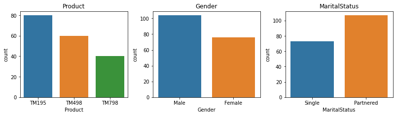

```python
# Creating a list of categorical columns to be used to plot countplots for each category on a single plot
category_col = ['Product', 'Gender', 'MaritalStatus']
plt.figure(figsize=(15, 12))

for i, name in enumerate(category_col):
    plt.subplot(4, 4, i + 1)
    sns.countplot(data =df, x=name)
    plt.tight_layout()
    plt.title(name)

plt.show()
```

Observations:

1. Most populat treadmill model is TM195, with TM498 being the second most popular and TM798 being the least popular of the three
2. Majority of the treadmills were purchased by males (account for more than 50%)
3. Majority of the customers are in a relationship

## Numerical Category Univariate Analysis

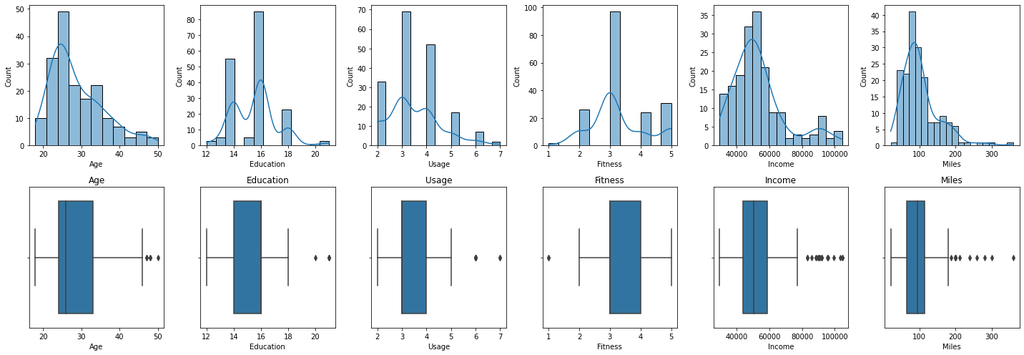

```python
# Create a list of numerical categories and then create subplots of histograms and box plots of each to visualize distribution and skewness
num_col = ['Age', 'Education', 'Usage', 'Fitness', 'Income', 'Miles']

plt.figure(figsize=(20, 7))

for i, name in enumerate(num_col):
    plt.subplot(2, 6, i + 1)
    sns.histplot(data=df, x=name, kde=True)
    plt.subplot(2, 6,len(num_col)+1+i)
    sns.boxplot(data=df, x=name)
    plt.tight_layout()
    plt.title(name)

plt.show()
```

Observations:

1. All numerical categories (Age, Education, Usage, Fitness, Income and Miles) contain outliers
2. Age, Income and Miles are exhibit rightly skewed distribution
3. For Age, 50% of the customers are within the 24 - 33 year old range
4. For Education, 50% of the customers have 14 - 16 years of education and 75% have 12 - 16 years
5. On average, the customer wants to use the treadmill 3 times per week, with the max at 5 times a week. Outliers show some wanted to use the treadmill 6/7 times a week
6. Customers shopping for treadmills rated themselves as relatively fit seeing that 50% self rated their fitness between 3-4 on a scale out of 5. Minimum rating was a 2/5, max was 5/5 and outliers at 1/5.
7. Median income was around 50k dollars and roughly 50% falling between 40k - 60k dollars. Majority of the income falls in the lower end but there are several outliers past $78k
8. For miles expected to be ran, the median was around 100 miles. Majority fall under 200 miles but there are several outliers between 200-300 miles and an outlier past 300 miles.

# Multivariate Data Analysis

## Heatmap and Pairplot

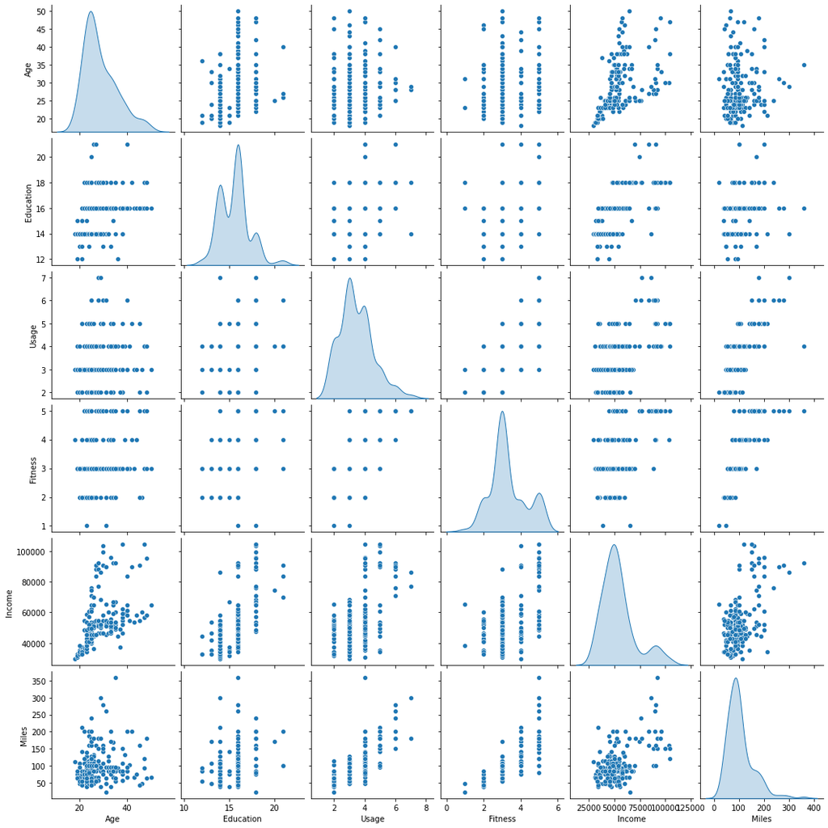

```python
# Plotting pairplot to visualise how the numerical categories are associated with each other
sns.pairplot(data=df, diag_kind='kde');
```

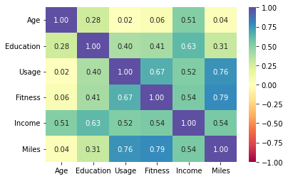

```python
# Plotting heatmap to support previous assessment. Looking at how each numerical variable correlate to each other
corr = df.corr()
sns.heatmap(corr, annot=True, vmin=-1, vmax=1, fmt=".2f", cmap="Spectral");
```

Observations from both pairplot and heatmap:

1. Miles has a high positive correlation with usage and fitness and vice versa
2. Age only has a positive correlation with Income and Education and minimal correlation with Usaage, Fitness and Miles
3. Education has a positive correlation with Income
4. Usage also has a positive correlation with Fitness, Income and Education
5. Fitness also has a positive correlation with Education, Fitness, Miles and Usage
6. Need to dig deeper to determine characteristics of the customer for the different models

## Line Module Plot

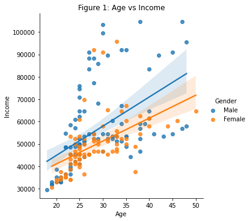

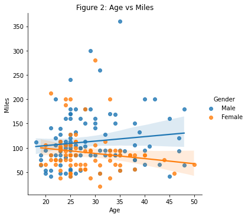

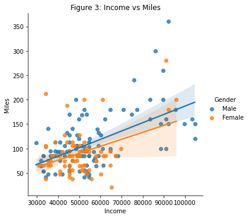

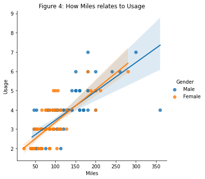

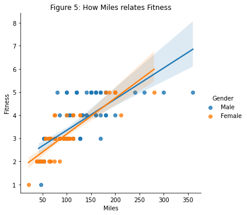

```python
# Plotting some line plots with best fit to see how the selected variables relate to each other.
#Really just looking to reinforce the observations made from the heatmap and pairplot but also looking to see how the trend looks wrt Gender
plt.figure(1,figsize=(15,12))
sns.lmplot(data=df, x='Age', y='Income', hue='Gender');
plt.title('Figure 1: Age vs Income')


plt.figure(2,figsize=(15,12))
sns.lmplot(data=df, x='Age', y='Miles', hue='Gender');
plt.title('Figure 2: Age vs Miles')

plt.figure(3,figsize=(15,2))
sns.lmplot(data=df, x='Income', y='Miles', hue='Gender');
plt.title('Figure 3: Income vs Miles')

plt.figure(4)
sns.lmplot(data=df, x='Miles', y='Usage', hue='Gender');
plt.title('Figure 4: How Miles relates to Usage')

plt.figure(5)
sns.lmplot(data=df, x='Miles', y='Fitness', hue='Gender');
plt.title('Figure 5: How Miles relates Fitness')

plt.show()
```

Observations:

1. Overall trends match what we saw in the pairplot and heatmap
2. For the most part, Male and Female customers exhibit similar trends for the categories except for Age vs Miles expected to run. For this one, men exhibit a positive correlation and expect to run more miles the older the customer is where as women exhibit a negative correlation and expect to run less the older the customer is. Should be noted that the trend for mens has a shallow positive slope so the increased expectations isn't drastic.
3. The more miles a customer expects to run, the higher their self-assessed fitness rating and expected usage per week
4. The higher the income, the higher the miles expected to run each year
5. Higher the age, higher the income

## Categorical Boxplot

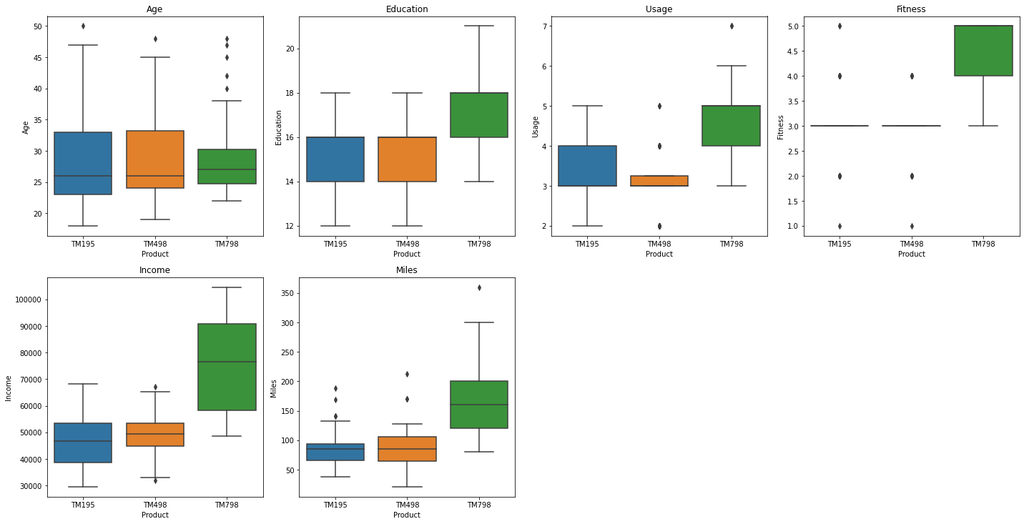

```python
# Digging into the demographics of customers who buy each treadmill model and looking at the distribution of model per age, education, fitness level, income, usage, income and miles intended to be ran
# Will utilize the num_col list created earlier

# Setting figure size for boxplot
plt.figure(1,figsize=(20,20))
#plt.figure(2,figsize=(20,20))

# Plotting multiple boxplots on Figure 1. Want to look at how the distribution is for product based on the various categories
for i, name in enumerate(num_col):
    plt.figure(1)
    plt.subplot(4, 4, i + 1)
    sns.boxplot(data=df, x='Product', y=name)
    #plt.figure(2)
    #plt.subplot(4,4,i+1)
    #sns.swarmplot(data=df, x='Product', y=name, size=4)
    plt.tight_layout()
    plt.title(name)

plt.show()
```

```python
# Looking into how many men and women buy each treadmill model
df.groupby(['Product'])['Gender'].value_counts()
```

```
Product  Gender
TM195    Female    40
         Male      40
TM498    Male      31
         Female    29
TM798    Male      33
         Female     7
Name: Gender, dtype: int64
```

```python
# Grouping by Product and Gender and analyzing the average age for the groups
df.groupby(['Product', 'Gender'])['Age'].mean()
```

```
Product  Gender
TM195    Female    28.450000
         Male      28.650000
TM498    Female    29.103448
         Male      28.709677
TM798    Female    27.000000
         Male      29.545455
Name: Age, dtype: float64
```

```python
# Grouping by Product and Gender and analzing average intended use per week
df.groupby(['Product', 'Gender'])['Usage'].mean()
```

```
Product  Gender
TM195    Female    2.900000
         Male      3.275000
TM498    Female    3.137931
         Male      3.000000
TM798    Female    5.000000
         Male      4.727273
Name: Usage, dtype: float64
```

```python
# Grouping by Product and Gender and analyzing average, self-assessed Fitness level per group
df.groupby(['Product', 'Gender'])['Fitness'].mean()
```

```
Product  Gender
TM195    Female    2.875000
         Male      3.050000
TM498    Female    2.862069
         Male      2.935484
TM798    Female    4.571429
         Male      4.636364
Name: Fitness, dtype: float64
```

Observations of boxplots and Group Averages:

1. For each model, you see a significant amoung of customers in the 23 - 34 age range with the median being around 26-27 years.
2. 50% of the customers who buy the TM195 and TM498 treadmills have between 14-16 years of education where as TM798 customers lie between 16-18 years of education
3. Customers who buy the TM798 treadmill intend to use the treadmill more per week, run more miles per year and have a higher income than the customers who get the other two models. They also rate themselves as more fit compared to the other demographics as 50% of the customers rated themselves between 4-5
4. The gender demographics for TM195 is equal between male and females where as there were more males for the other two models

## Categorical Plot

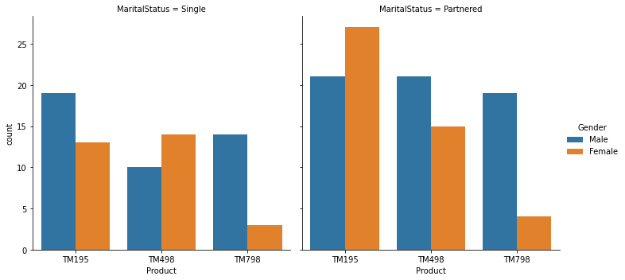

```python
# Creating categorical plots to look more into the demographic breakdown of the models

plt.figure(1,figsize=(15,12))
sns.catplot(data=df, x='Product', col='MaritalStatus', hue='Gender', kind='count');

#plt.figure(2,figsize=(15,12))
#sns.catplot(data=df, x='Product', col='Gender', hue='MaritalStatus', kind='count')
```

Observations:

1. More single men buy the TM195 and TM798 than single women, where as single women buy more TM498
2. More partnered women buy the TM195 where as more partnered men buy the TM498 and TM798

# Conclusion

Based off the data, I have made the following observations and recommendations of each model:

*TM195:*

Characteristics of customers tend to:

1. Be in the age range of 23-34 years
2. Have 14-16 years of education
3. Expect to use treadmill 3-4 times a week and run less than 100 miles a year
4. Rate themselves as average fitness (3/5)
5. Have income between roughly $40k - 55k
6. Equally be male or female

*TM498:*

Characteristics of customers tend to:

1. Be in the age range of 24-34 years
2. Have 14-16 years of education
3. Expect to use treadmill 3 times a week and have a larger range of miles expected to be ran than the TM195 (roughly between 60-110 miles)
4. Rate themselves as average fitness (3/5)
5. Have income between roughly $45k - 55k

*TM798:*

Characteristics of customers tend to:

1. Be in the age range of 24-30
2. Have higher years of education (16-18 years) than the other two models
3. Have higher expected usage per week and expected miles ran than the other two models
4. Consider themselves more fit than the other two
5. Have a higher income and significantly larger income range
6. Are mainly male customers

*Recommendations:*

1. Should focus on targetting the younger demographic (mid 20s to mid 30s)
2. Based off data, the models should be tiered. The TM798 is the higher tier as it attracts the more serious (higher usage and miles expected to be ran), fit and wealthier demographic. The other two are mid class and have overlapping demographics but the TM195 attracts customers who intend to use the treadmill slightly more per week than the TM498
3. Customer base is also partnered more than singled
4. More data should be collected on price per model and it could be useful to understand per state breakdown if this is a national brand/store. Some states like Colorado tend to be more active than others and can help identify opportunistic areas
5. More data could be gathered on Marital Status. Right now it's limited to partnered and single but could include divorcees